# Data display, ggplot2

```r
library(ggplot2)
library(dplyr)
library(plyr)
library(leaps)
data <- read.csv('./data/pu_ssocs10.csv', sep='\t')
```

# Data Exploration and examination

Our data comes from the National Center for Education Statistics’ 2009-2010 School Survey on Crime and Safety. It The data is accompanied by a thorough write-up on initial treatment of the data.

First we pulled in the full CSv of all 400 variables. Many of the columns are simply imputation flags for previous columns. A great deal of imputation has been done on the data, and entries of -1 were entered for questions left unanswered by a school. We examined the data to see which, if any columns were too incomplete to be useful.

```r
cols <- c()
nas <- c()

for (col in colnames(data)) {
  perc_na <- sum(data[,col] %in% c(-2, -1, NA)) / nrow(data)
  cols <- c(cols, col)
  nas <- c(nas, perc_na)
}

data_na <- data.frame(cols, nas)
colnames(data_na) <- c('col', 'perc_na')
data_na[order(-data_na$perc_na),]$col[43:194] # remove resampling, imputation, X, and all columns with NA
```

```
##   [1] SCHID     C0110     C0112     C0114     C0116     C0120     C0122
##   [8] C0124     C0126     C0128     C0130     C0132     C0134     C0136
##  [15] C0138     C0140     C0141     C0142     C0143     C0144     C0146
##  [22] C0148     C0150     C0151     C0153     C0154     C0158     C0162
##  [29] C0166     C0169     C0170     C0171     C0173     C0174     C0176
##  [36] C0178     C0180     C0181     C0182     C0184     C0186     C0190
##  [43] C0192     C0194     C0196     C0198     C0200     C0202     C0204
##  [50] C0206     C0208     C0210     C0212     C0214     C0216     C0218
##  [57] C0220     C0266     C0268     C0269     C0270     C0272     C0274
##  [64] C0276     C0277     C0280     C0282     C0284     C0286     C0288
##  [71] C0290     C0292     C0294     C0296     C0298     C0300     C0302
##  [78] C0304     C0306     C0308     C0374     C0376     C0378     C0379
##  [85] C0380     C0382     C0384     C0386     C0388     C0389     C0390
##  [92] C0391     C0393     C0394     C0398     C0402     C0406     C0410
##  [99] C0414     C0418     C0422     C0426     C0430     C0434     C0438
## [106] C0442     C0446     C0450     C0454     C0518     C0520     C0526
## [113] C0528     C0532     C0534     C0536     C0538     C0560     C0562
## [120] C0568     C0570     C0572     C0578_YY  CRISIS10  DISTOT10  INCID10
## [127] INCPOL10  OTHACT10  OUTSUS10  PROBWK10  REMOVL10  STRATA    STUOFF10
## [134] SVINC10   SVPOL10   TRANSF10  VIOINC10  VIOPOL10  DISFIRE10 DISDRUG10
## [141] DISWEAP10 GANGHATE  DISRUPT   DISATT10  DISALC10  SEC_FT10  SEC_PT10
## [148] FR_LVEL   FR_SIZE   FR_URBAN  PERCWHT   FINALWGT
## 401 Levels: C0014_R C0016_R C0110 C0112 C0114 C0116 C0120 C0122 ... X
```

From the remaining columns, we found a few interesting features to examine more closely. In particular, we are interested in

1. Can the total number of violent incidences on a campus be predicted by anything? Does training for teachers make a difference in how many cases occur/how many get reported to the police? Is there any association between attendance and crime on campus?
2. Whether or not attendance is a predictor of crime, does crime affect attendance? Does anything else–taking away bus privileges, for example? High crime in the area?
3. Do violence drills (bomb threat drills, shooter drills, etc) have any effect on the occurence of violence on campuses?
4. Does having random drug sniffs affect crime incidents on campus, violent or otherwise?

We grab the relevant columns and rename them for clarity.

```r
newdata <- select(data,
                   #Predictors
                   C0568, C0452, C0436, DISRUPT,SVPOL10, C0560,
                   C0538,INCPOL10, GANGHATE, C0294, C0156, C0172, C0124, C0276, C0277, C0272, DISTOT10, DISDRUG10)

newdata <- rename(newdata, c("C0568" = "Attendance","C0452" = "Losspriv",
                  "C0436" =  "Lossbus", "DISRUPT" = "Numdisrpt",
                  "SVPOL10" = "srs_to_police", "C0560" = "Crime_nbhd",
                  "C0538" = "Classchange", "INCPOL10" = "Incpol",
                  "GANGHATE" = "GANGHATE", "C0294" = "Lack_of_funds", "C0156" ="shootingdrills", "C0172" = "threatdrills", "C0124"="Dogsniffs", "C0276" = "Posbehav", "C0277" = "crisistraining", "C0272"= "warntraining", "DISTOT10"= "DISTOT", "DISDRUG10" = "DISDRUG"))
```

In the data description it is mentioned that although a lot of imputation has been done on the data to ensure logical coherence, etc, one column that was left alone was the percent daily attendance. It is further suggested that there is reason to believe some responders may have misinterpretted the question to be about daily percent *absences*, resulting in outlandishly low estimates in some cases.

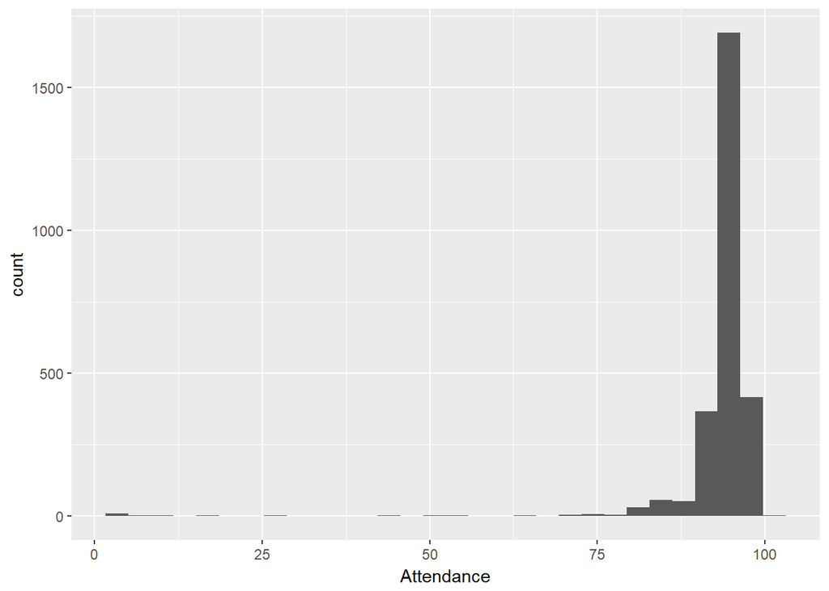

```r
ggplot(newdata, aes(Attendance)) + geom_histogram()
```

The number of such cases appears to be small, but possibly not insignificant. We will perform our own imputation according to this assumption by imputing x->100-x for reports below 25%. This is a very conservative adjustment, and will probably leave many erroneous reports uncorrected.

```r
newdata$Attendance <- sapply(newdata$Attendance, function(x) ifelse(x > 25, x, 100-x))
```

Many of the types of analysis we would like to do are limited by the privacy suppression of the data. Many of the predictor and response variables that might have been continuous/numerical have been binned and made categorical. Many others are discrete counts (like total number of incidents), making linear regression inappropriate, since, among other things, descrete errors cannot be normally distributed. We may consider Poisson regression for some analyses with these variables.

The method of sampling also requires attention: schools were thoroughly stratefied. The pdf gives details of adjustments that need to be made on estimates of various statisticts.

In any case, we can still look at the effect size of various predictors: for example, is the average number of crimes significantly higher in schools that drill for crimes? Is it lower in schools that have violence prevention training for teachers?

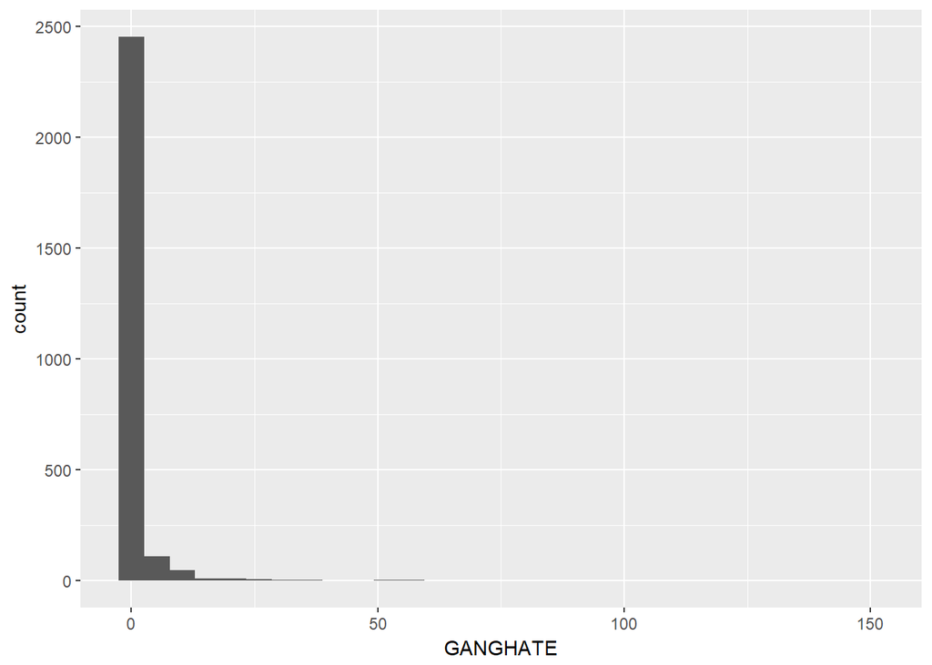

```r
ggplot(newdata, aes(GANGHATE))+geom_histogram()
```

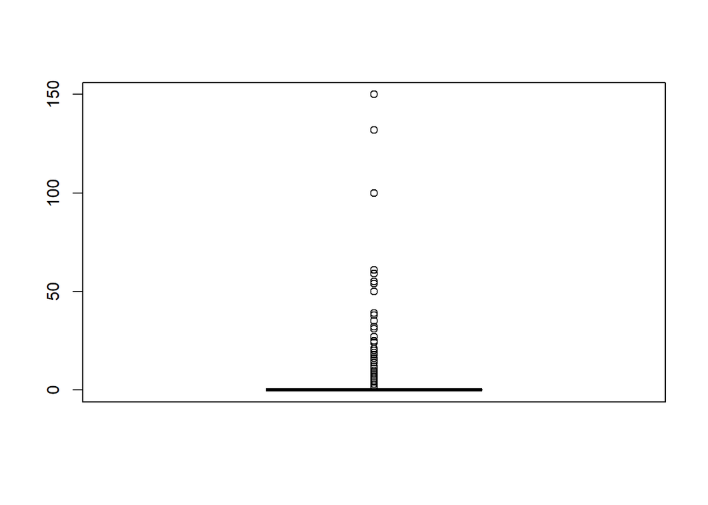

```r
boxplot(newdata$GANGHATE)
```

Similarly, the majority of schools had very few incidents reported to the police, but one school reported as many as 1240 in one year.

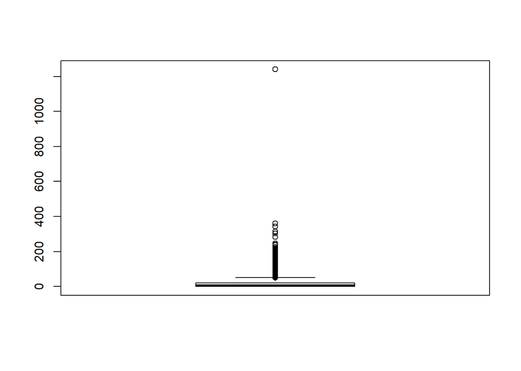

```r
boxplot(newdata$Incpol)
```

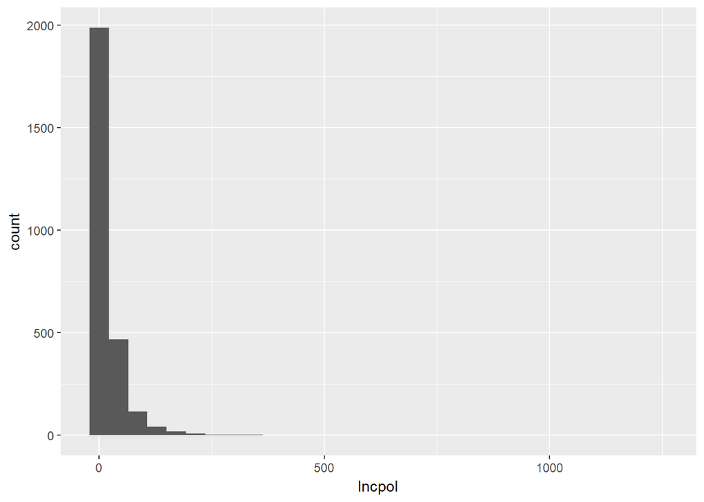

```r
ggplot(newdata, aes(Incpol))+geom_histogram()
```

In exploring the question about attendance as a response variable, we examine the scatter plots to check for any patterns.

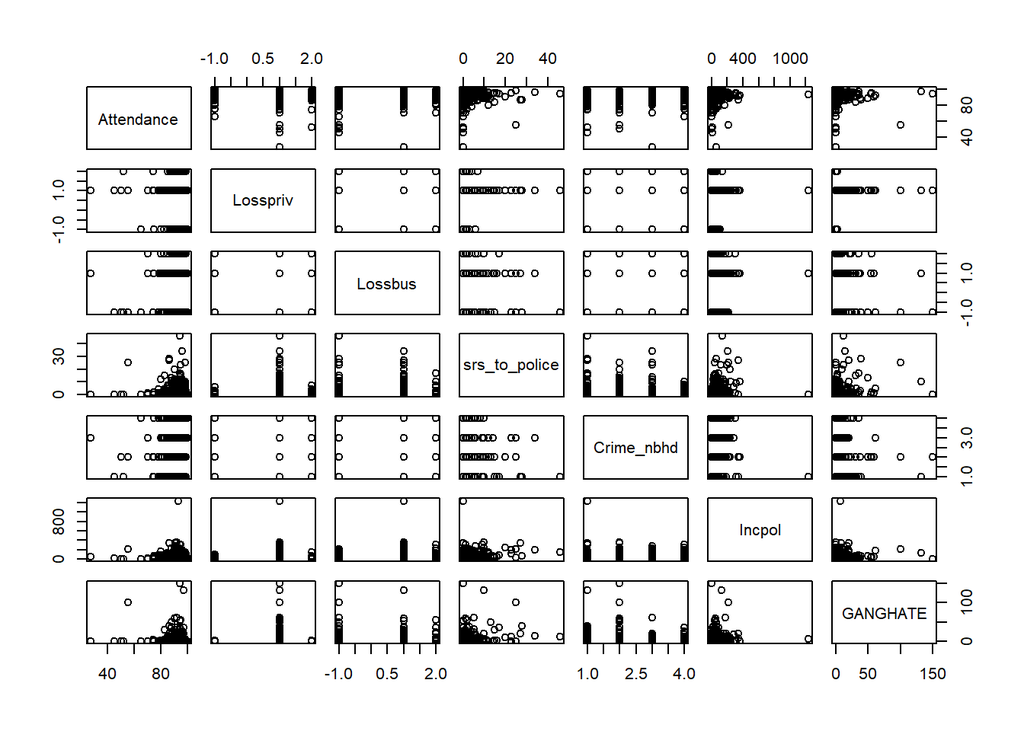

```r
att <- data.frame(newdata$Attendance,newdata$Losspriv,newdata$Lossbus,newdata$srs_to_police,newdata$Crime_nbhd,newdata$Incpol,newdata$GANGHATE)
colnames(att) <- c("Attendance", "Losspriv", "Lossbus", "srs_to_police", "Crime_nbhd", "Incpol", "GANGHATE")
plot(att)
```

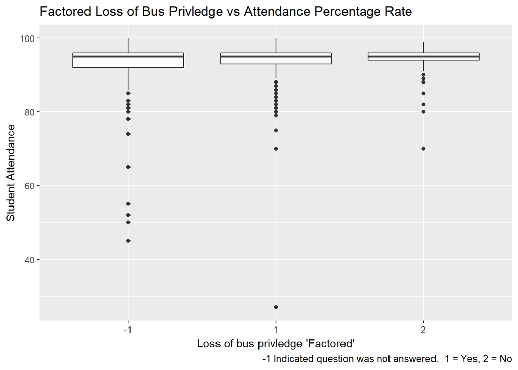

```r
newdata %>%
  group_by(Lossbus) %>%
  ggplot(., aes(factor(Lossbus), Attendance)) +
  geom_boxplot() + ggtitle("Factored Loss of Bus Privledge vs Attendance Percentage Rate") +
  xlab("Loss of bus privledge 'Factored'") + ylab("Student Attendance") +
  labs(caption = "-1 Indicated question was not answered.  1 = Yes, 2 = No") +
  ggsave("Factored Loss of Bus Privledge vs Attendance Percentage Rate.png")
```

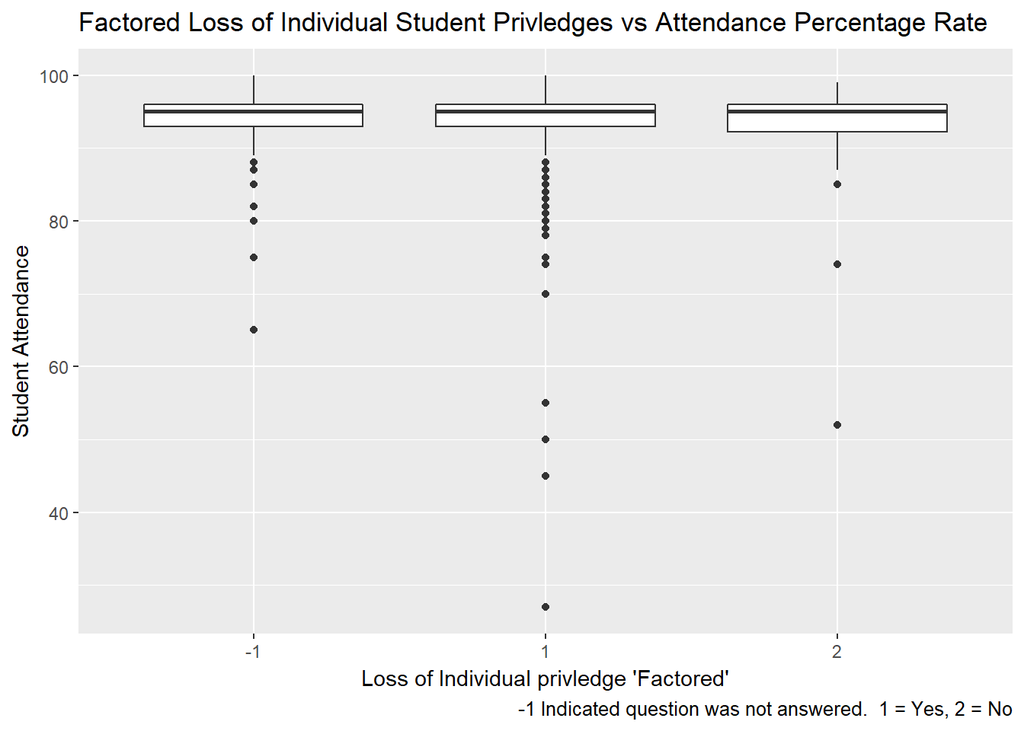

```r
#Loss of individual privledges vs Attendance
newdata %>%
  group_by(Losspriv) %>%
  ggplot(., aes(factor(Losspriv), Attendance)) +
  geom_boxplot() + ggtitle("Factored Loss of Individual Student Privledges vs Attendance Percentage Rate") +
  xlab("Loss of Individual privledge 'Factored'") + ylab("Student Attendance") +
  labs(caption = "-1 Indicated question was not answered.  1 = Yes, 2 = No") +
  ggsave("Factored Loss of Individual Student Privledges vs Attendance Percentage Rate.png")
```

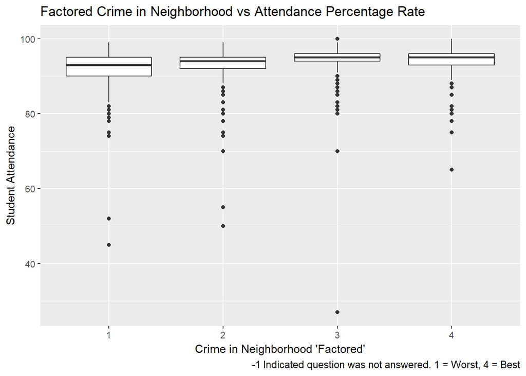

```r
#Crime in Neighborhood vs Attendance
newdata %>%
  group_by(Crime_nbhd) %>%
  ggplot(., aes(factor(Crime_nbhd), Attendance)) +
  geom_boxplot() + ggtitle("Factored Crime in Neighborhood vs Attendance Percentage Rate") +
  xlab("Crime in Neighborhood 'Factored'") + ylab("Student Attendance") +
  labs(caption = "-1 Indicated question was not answered. 1 = Worst, 4 = Best") +
  ggsave("Factored Crime in Neighborhood vs Attendance Percentage Rate.png")
```

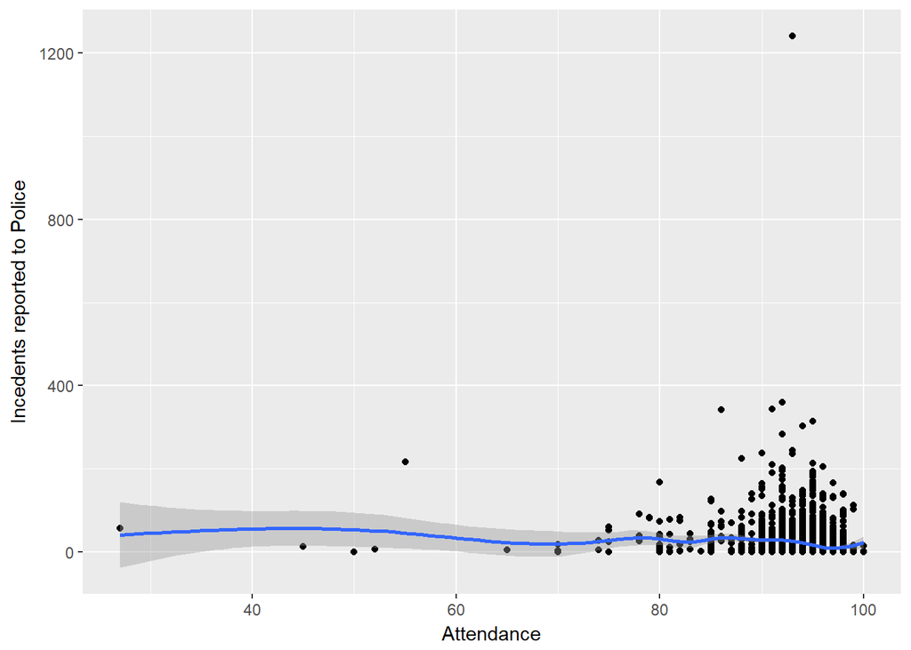

```r
#Incedents reported to Police vs Attendance
qplot(Attendance,Incpol, data = newdata,
      geom = c("point", "smooth")) + ylab("Incedents reported to Police") +
  ggsave("Attendance vs Police.png")
```

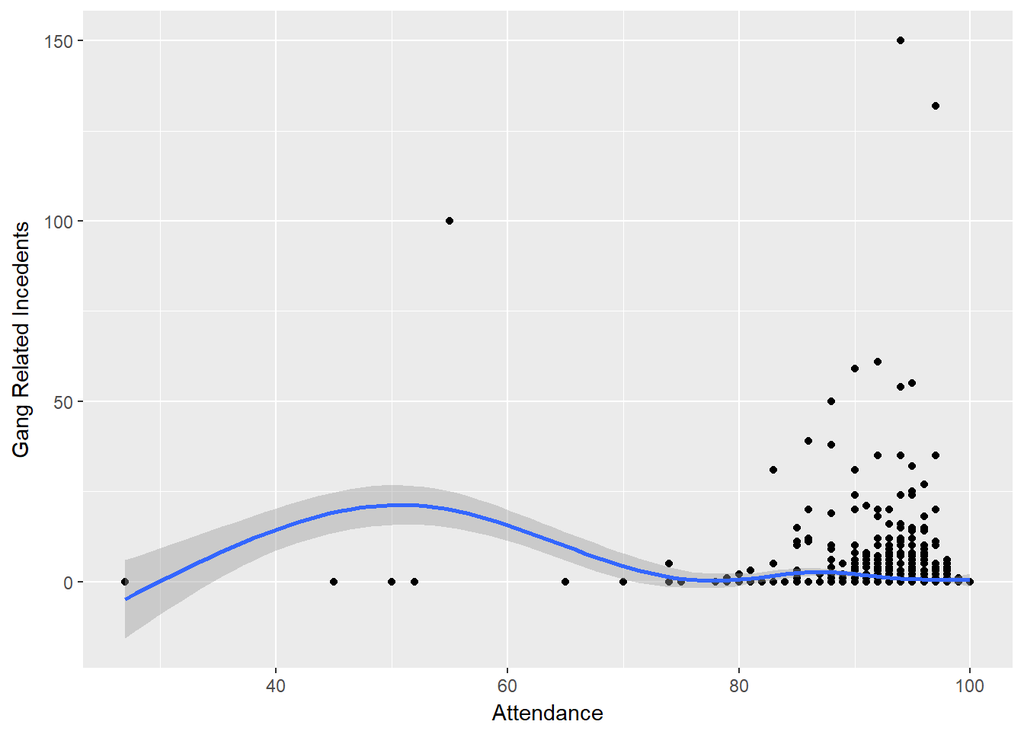

```r
#Gang Related Incedents vs Attendance
qplot(Attendance, GANGHATE, data = newdata,
      geom= c("point", "smooth")) + ylab("Gang Related Incedents") +
  ggsave("Attendance vs Gang activity.png")
```

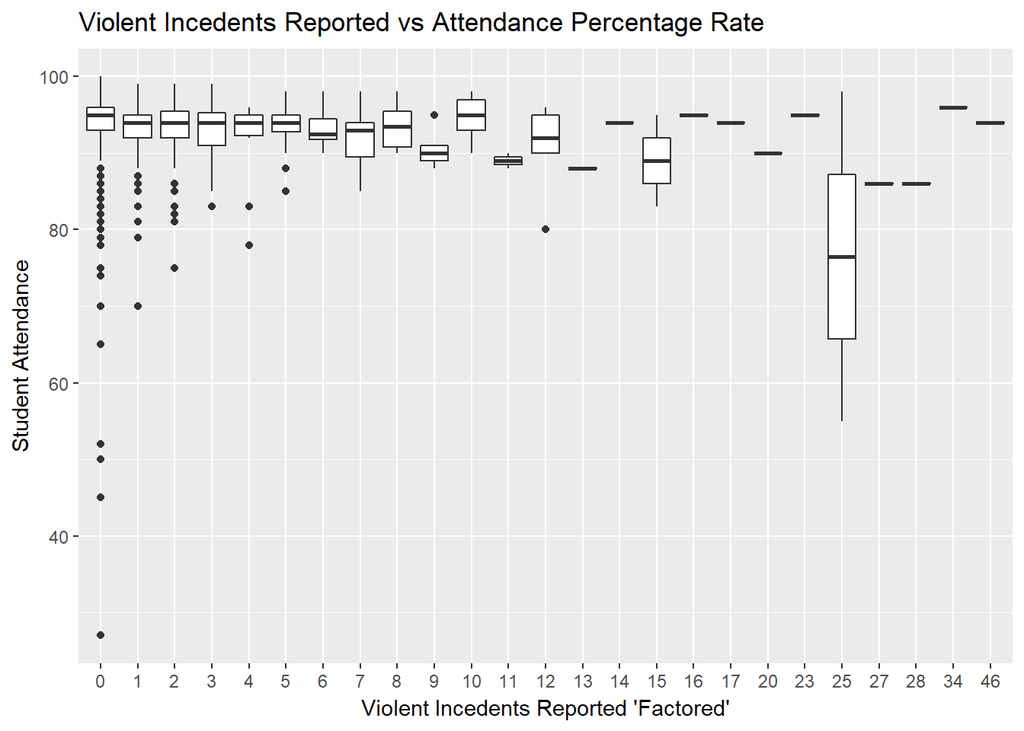

```r
#Violent Incedents Reported to Police vs Attendance
newdata %>%
  group_by(srs_to_police) %>%
  ggplot(., aes(factor(srs_to_police), Attendance)) +
  geom_boxplot() + ggtitle("Violent Incedents Reported vs Attendance Percentage Rate") +
  xlab("Violent Incedents Reported 'Factored'") + ylab("Student Attendance")
```

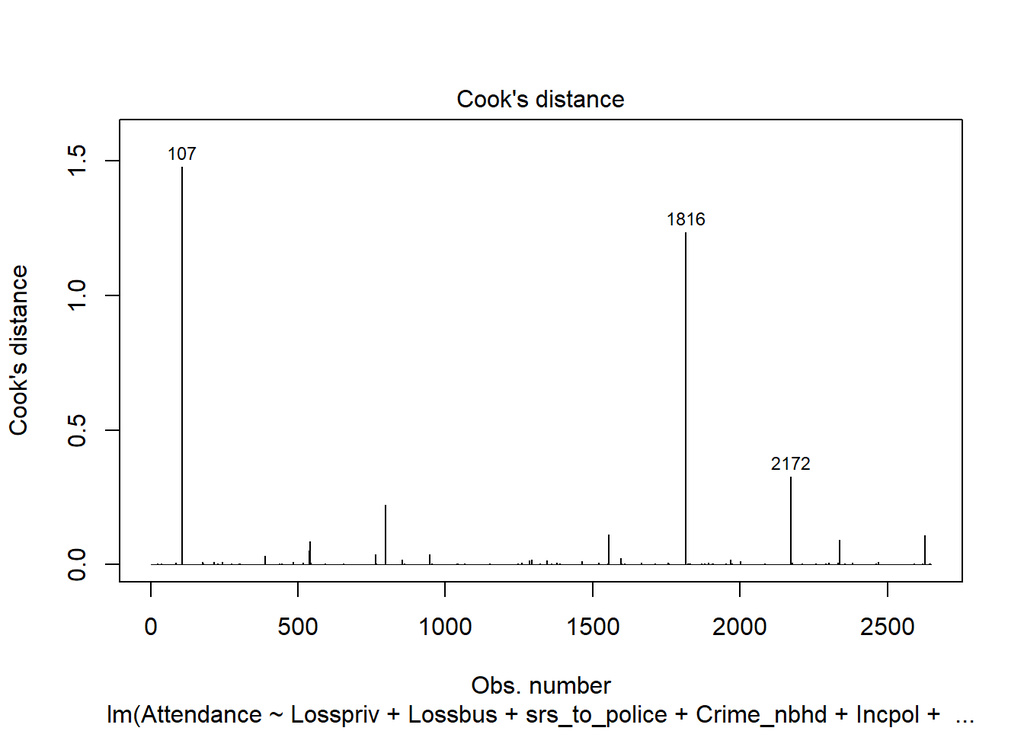

```r
att.viol.lm <- lm(Attendance ~ Losspriv + Lossbus + srs_to_police + Crime_nbhd + Incpol + GANGHATE, data = newdata)
att.viol.summ <- summary(att.viol.lm)
plot(att.viol.lm, which = 4)
```

A look at the Cook’s distance for the data in our naive linear model for predicting attendance shows that a number of data points may have outsize influence on the model.

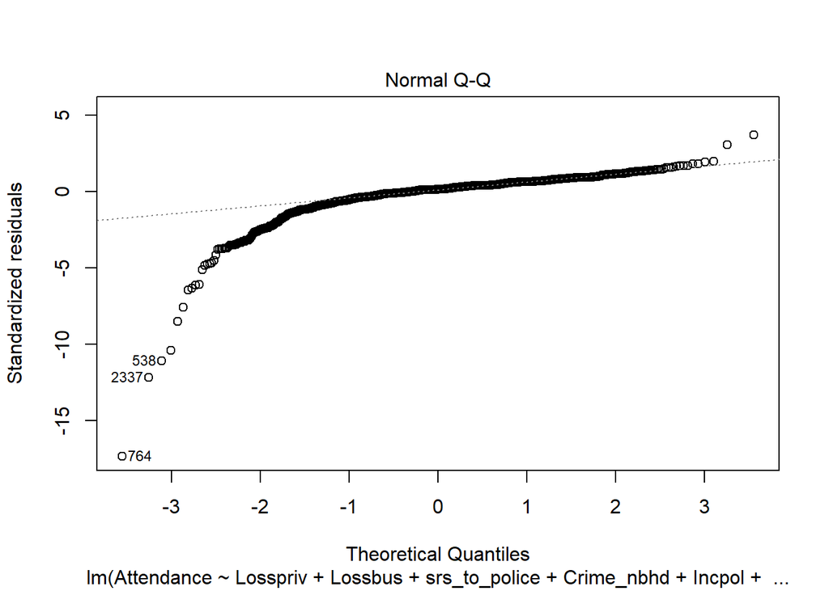

```r
plot(att.viol.lm, which = 2)
```

We also have some pretty heavy tails.

```r
att.viol.summ
```

```
##
## Call:
## lm(formula = Attendance ~ Losspriv + Lossbus + srs_to_police +
##     Crime_nbhd + Incpol + GANGHATE, data = newdata)
##
## Residuals:
##     Min      1Q  Median      3Q     Max
## -66.967  -0.908   0.583   1.790  11.326
##
## Coefficients:
##                Estimate Std. Error t value Pr(>|t|)
## (Intercept)   91.542711   0.335982 272.463  < 2e-16 ***
## Losspriv       0.081532   0.176049   0.463   0.6433
## Lossbus        0.442743   0.095034   4.659 3.34e-06 ***
## srs_to_police -0.067424   0.036924  -1.826   0.0680 .
## Crime_nbhd     0.801016   0.098284   8.150 5.56e-16 ***
## Incpol        -0.008830   0.001955  -4.516 6.58e-06 ***
## GANGHATE      -0.034937   0.013715  -2.547   0.0109 *
## ---
## Signif. codes:  0 '***' 0.001 '**' 0.01 '*' 0.05 '.' 0.1 ' ' 1
##
## Residual standard error: 3.859 on 2641 degrees of freedom
## Multiple R-squared:  0.06117,    Adjusted R-squared:  0.05904
## F-statistic: 28.68 on 6 and 2641 DF,  p-value: < 2.2e-16
```

Before trying a reduced model, we take a side-track to test the hypothesis that taking away bus privileges as a form of punishment affects mean attendance.

```r
all.bus <- data.frame(matrix(c(newdata$Attendance,newdata$Lossbus),ncol=2))
colnames(all.bus) <- c("Attendance", "Lossbus")
all.bus <- all.bus[all.bus$Lossbus != -1,]

t.test(Attendance ~ Lossbus, paired = FALSE, var.equal = FALSE, data = all.bus)
```

```
##
##  Welch Two Sample t-test
##
## data:  Attendance by Lossbus
## t = -2.6606, df = 401.37, p-value = 0.008112
## alternative hypothesis: true difference in means is not equal to 0
## 95 percent confidence interval:
##  -0.9099333 -0.1366427
## sample estimates:
## mean in group 1 mean in group 2
##        94.08917        94.61246
```

Before moving on to eliminating variables, we try the same model again with severe outliers removed to see if we get any improvement.

```r
##Finding and dealing with outliers
#scale(newdata)
outdet <- function(x) abs(scale(x)) >= 3
newdata1 <- newdata[!apply(sapply(newdata, outdet), 1, any), ]

att.viol.lm.clean <- lm(Attendance ~ Losspriv + Lossbus + srs_to_police + Crime_nbhd + Incpol + GANGHATE, data = newdata1)
summary(att.viol.lm)
```

```
##
## Call:
## lm(formula = Attendance ~ Losspriv + Lossbus + srs_to_police +
##     Crime_nbhd + Incpol + GANGHATE, data = newdata)
##
## Residuals:
##     Min      1Q  Median      3Q     Max
## -66.967  -0.908   0.583   1.790  11.326
##
## Coefficients:
##                Estimate Std. Error t value Pr(>|t|)
## (Intercept)   91.542711   0.335982 272.463  < 2e-16 ***
## Losspriv       0.081532   0.176049   0.463   0.6433
## Lossbus        0.442743   0.095034   4.659 3.34e-06 ***
## srs_to_police -0.067424   0.036924  -1.826   0.0680 .
## Crime_nbhd     0.801016   0.098284   8.150 5.56e-16 ***
## Incpol        -0.008830   0.001955  -4.516 6.58e-06 ***
## GANGHATE      -0.034937   0.013715  -2.547   0.0109 *
## ---
## Signif. codes:  0 '***' 0.001 '**' 0.01 '*' 0.05 '.' 0.1 ' ' 1
##
## Residual standard error: 3.859 on 2641 degrees of freedom
## Multiple R-squared:  0.06117,    Adjusted R-squared:  0.05904
## F-statistic: 28.68 on 6 and 2641 DF,  p-value: < 2.2e-16
```

We seek a reduced model.

```r
allpossreg <- regsubsets(Attendance ~ .,
                         nbest=6, data=att)

aprout <- summary(allpossreg)

with(aprout,round(cbind(which,rsq,adjr2,cp,bic),3)) ### AIC is not an option
```

```
##   (Intercept) Losspriv Lossbus srs_to_police Crime_nbhd Incpol GANGHATE
## 1           1        0       0             0          1      0        0
## 1           1        0       0             0          0      1        0
## 1           1        0       1             0          0      0        0
## 1           1        0       0             1          0      0        0
## 1           1        0       0             0          0      0        1
## 1           1        1       0             0          0      0        0
## 2           1        0       0             0          1      1        0
## 2           1        0       1             0          1      0        0
## 2           1        0       0             1          1      0        0
## 2           1        0       0             0          1      0        1
## 2           1        1       0             0          1      0        0
## 2           1        0       1             0          0      1        0
## 3           1        0       1             0          1      1        0
## 3           1        0       0             0          1      1        1
```

[output cut: 49 more lines]

We now move on to the question of whether disaster drills relating to violence affect the mean number of violent incidents. We first check to see if any schools have ommited information about drills and remove them.

```r
unique(newdata$shootingdrills)
```

```
## [1]  1 -1  2
```

```r
unique(newdata$threatdrills)
```

```
## [1]  2 -1  1
```

```r
drills <- data.frame(matrix(c(newdata$srs_to_police, newdata$Incpol, newdata$shootingdrills, newdata$threatdrills), ncol = 4))
colnames(drills) <- c("srs_to_police", "Incpol", "shootingdrills", "threatdrills")
drills.shoot <- drills[drills$shootingdrills != -1,]

t.test(srs_to_police~ shootingdrills, paired = FALSE, var.equal = FALSE, data = drills.shoot)
```

```
##
##  Welch Two Sample t-test
##
## data:  srs_to_police by shootingdrills
## t = 0.41079, df = 1591.4, p-value = 0.6813
## alternative hypothesis: true difference in means is not equal to 0
## 95 percent confidence interval:
##  -0.1612006  0.2466094
## sample estimates:
## mean in group 1 mean in group 2
##       0.5987903       0.5560859
```

```r
drills.threat <- drills[drills$threatdrills != -1,]
t.test(srs_to_police~ threatdrills, paired = FALSE, var.equal = FALSE, data = drills.threat)
```

```
##
##  Welch Two Sample t-test
##
## data:  srs_to_police by threatdrills
## t = 1.0143, df = 1618.1, p-value = 0.3106
## alternative hypothesis: true difference in means is not equal to 0
## 95 percent confidence interval:
##  -0.1074112  0.3374705
## sample estimates:
## mean in group 1 mean in group 2
##       0.6557576       0.5407279
```

And again we fail to reject the null hypothesis. It seems that other violence-related drills also do not affect serious crime reports.